# Analyzing roulette strategies

Qianyi Sun

# 1 Introduction

A roulette table composed of 38 (or 37) evenly sized pockets on a wheel. The pockets are colored red, black, or green. The pockets are also numbered. Roulette is a game of chance in which a pocket is randomly selected. Gamblers may wager on several aspects of the outcome. For example, one may place a wager that the randomly selected pocket will be red or odd numbered or will be a specific number.

For this game, all one needs to know is that there are 38 pockets of which 2 are green, 18 are red, and 18 are black. The payout for a bet on black (or red) is $1 for each $1 wagered. This means that if a gambler bets $1 on black and the randomly selected pocket is black, then the gambler will get the original $1 wager and an additional $1 as winnings.(quoted from https://github.com/thomasgstewart/data-science-5620/blob/master/deliverables/01-roulette.md)

# 2 Solutions to questions

## 2.1 Question 1

Q1:You should explain how you used computer simulation to calculate the average earnings of a gambler that uses this strategy. As part of the explanation, provide a figure (or a series of figures) that show how the gamblers earnings (or losses) evolve over a series of wagers at the roulette wheel. (The x-axis will be the wager number (or play number), the y-axis will be earnings.) The code below provides all the functions you’ll need to calculate average earnings.

For Q1, first of all, to solve this question, we need to find the relative variables to create a figure to observe how gambler earnings evolve a series of wagers at the roulette wheel.Thus, we at least must know how to attain x-axis and y-axis. By reading question, we can see that x-axis is wager number and y-axis is earnings. Then for wager number, how can we get it? In order to get wager number, we should understand one_series() function. Within the one_series code, it set initial state like B number which is the starting budget and W number which is the budget threshold for successfully stoping. And it opens the vector to store budget over series of plays and create loop of plays. Thus in a word, one_series() is to set basic game rule and has contained the every change of budget’s values. So when we get the every change of budget’s values, we can Subtract it from the starting budget to get the change of gambler earning’s value. At this time, we can use plot() to draw a figure to solve Q1. The plot() is a drawing function. We can see the second chunk code to know a simple way to solve Q1.

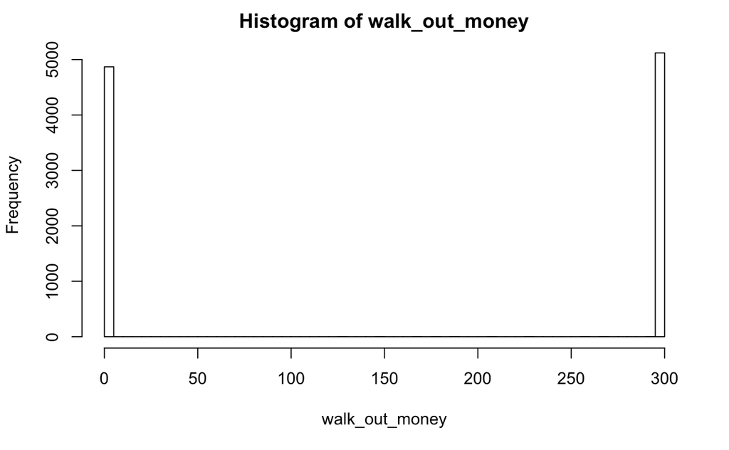

```r
library(dplyr)
one_play <- function(state){

    # Wager
    proposed_wager <- ifelse(state$previous_win, 1, 2*state$previous_wager)
    wager <- min(proposed_wager, state$M, state$B)

    # Spin of the wheel
    red <- rbinom(1,1,18/38)

    # Update state
    state$plays <- state$plays + 1
    state$previous_wager <- wager
    if(red){
      # WIN
      state$B <- state$B + wager
      state$previous_win <- TRUE
    }else{
      # LOSE
      state$B <- state$B - wager
      state$previous_win <- FALSE
    }
  state
}


#' Stopping rule
#'
#' Takes the state list and determines if the gambler has to stop
#' @param state A list.  See one_play
#' @return TRUE/FALSE
stop_play <- function(state){
  if(state$B <= 0) return(TRUE)
  if(state$plays >= state$L) return(TRUE)
  if(state$B >= state$W) return(TRUE)
  FALSE
}


#' Play roulette to either bankruptcy, success, or play limits
#'
#' @param B number, the starting budget
#' @param W number, the budget threshold for successfully stoping
#' @param L number, the maximum number of plays
#' @param M number, the casino wager limit
#' @return A vector of budget values calculated after each play.
one_series <- function(
    B = 200
  , W = 300
  , L = 1000
  , M = 100
){

  # initial state
  state <- list(
    B = B
  , W = W
  , L = L
  , M = M
  , plays = 0
  , previous_wager = 0
  , previous_win = TRUE
  )

  # vector to store budget over series of plays
  budget <- rep(NA, L)

  # For loop of plays
  for(i in 1:L){
    new_state <- state %>% one_play
    budget[i] <- new_state$B
    if(new_state %>% stop_play){
      return(budget[1:i])
    }
    state <- new_state
  }
  budget
}

# helper function
get_last <- function(x) x[length(x)]


# Simulation
walk_out_money <- rep(NA, 10000)
for(j in seq_along(walk_out_money)){
  walk_out_money[j] <- one_series(B = 200, W = 300, L = 1000, M = 100) %>% get_last
}

# Walk out money distribution
hist(walk_out_money, breaks = 100)
```

```r
# Estimated probability of walking out with extra cash
mean(walk_out_money > 200)
```

```
[1] 0.5125
```

```r
# Estimated earnings
mean(walk_out_money - 200)
```

```
[1] -46.1762
```

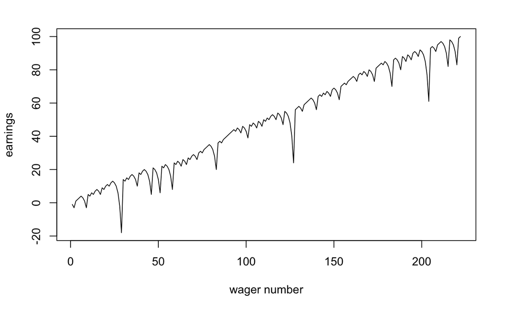

```r
earnings <- one_series(B = 200, W = 300, L = 1000, M = 100) - 200

#plot(x = wager_number, y = earnings, type = "l")
plot(earnings,type="l",xlab="wager number")
```